# Mini Project 2: Breast Cancer Dataset

# Intro

## Problem Statement

Due to the extremely high dimensionality of gene expression data, we apply **Principal Component Analysis (PCA)** for dimensionality reduction, to extract the dominant patterns of variance and visualize sample clustering.

Our goals:

- Understand patterns in gene expression that differentiate cancer subtypes.
- Use **PCA and clustering** to explore unsupervised structure in the data.
- Investigate which genes contribute most to principal components.
- Validate clustering results against known subtype labels.

This analysis may inform biomarker discovery or subtype classification strategies in cancer genomics.

```python
## load dataset
import pandas as pd

df = pd.read_csv("Breast_GSE45827.csv")
```

```python
# shape , columns , type
```

```python
print("Data Shape, rows x cols:", df.shape)
print("\n Data columns", df.columns)
print("\n types present in types column", df["type"].unique())
print("\n distribution of values in types column ", df["type"].value_counts())
```

```
Data Shape, rows x cols: (151, 54677)

 Data columns Index(['samples', 'type', '1007_s_at', '1053_at', '117_at', '121_at',
       '1255_g_at', '1294_at', '1316_at', '1320_at',
       ...
       'AFFX-r2-Ec-bioD-3_at', 'AFFX-r2-Ec-bioD-5_at', 'AFFX-r2-P1-cre-3_at',
       'AFFX-r2-P1-cre-5_at', 'AFFX-ThrX-3_at', 'AFFX-ThrX-5_at',
       'AFFX-ThrX-M_at', 'AFFX-TrpnX-3_at', 'AFFX-TrpnX-5_at',
       'AFFX-TrpnX-M_at'],
      dtype='object', length=54677)

 types present in types column ['basal' 'HER' 'cell_line' 'normal' 'luminal_A' 'luminal_B']

 distribution of values in types column  type
basal        41
HER          30
luminal_B    30
luminal_A    29
cell_line    14
normal        7
Name: count, dtype: int64
```

## Data Cleaning and EDA:

### Check for nulls

```python
df.isnull().sum()
```

```
samples            0
type               0
1007_s_at          0
1053_at            0
117_at             0
                  ..
AFFX-ThrX-5_at     0
AFFX-ThrX-M_at     0
AFFX-TrpnX-3_at    0
AFFX-TrpnX-5_at    0
AFFX-TrpnX-M_at    0
Length: 54677, dtype: int64
```

```python
labels = df['type']
data = df.drop(columns=['type'])  # 54676 genes
print("labels",labels)
print("\n data",data)
```

```
labels 0          basal
1          basal
2          basal
3          basal
4          basal
         ...
146    luminal_B
147    luminal_B
148    luminal_B
149    luminal_B
150    luminal_B
Name: type, Length: 151, dtype: object

 data      samples  1007_s_at   1053_at    117_at    121_at  1255_g_at   1294_at  \
0         84   9.850040  8.097927  6.424728  7.353027   3.029122  6.880079
```

[output cut: 64 more lines]

### EDA visualizations

- Boxplots for top-variance genes , to visualize the range of data
- Made histograms to see if data is skewed or see apparent patterns
- Produced a correlation matrix to see if any of the genes have relationships with each other

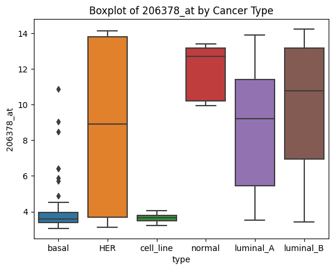

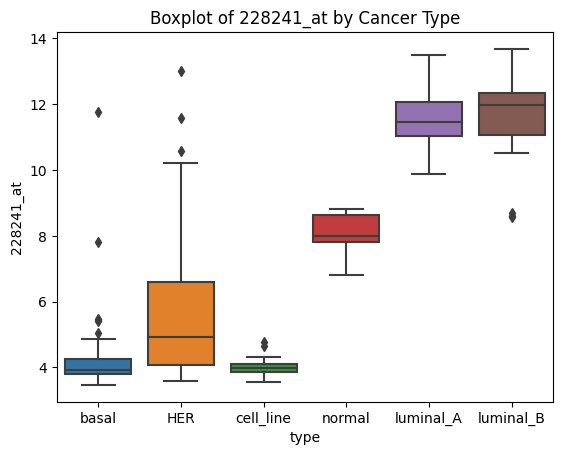

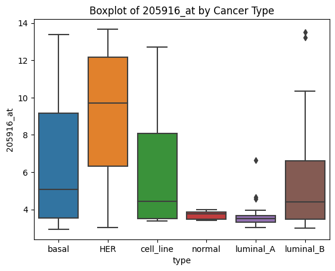

```python
# Variance of each gene (feature)
gene_variance = df.drop(columns=['samples','type']).var().sort_values(ascending=False)
top_genes = gene_variance.head(10).index

# Boxplots for top 3 features
import seaborn as sns
import matplotlib.pyplot as plt
for gene in top_genes[:3]:
    plt.figure()
    sns.boxplot(x=df['type'], y=df[gene])
    plt.title(f'Boxplot of {gene} by Cancer Type')
```

# histogram

```
array([[<Axes: title={'center': '206378_at'}>,
        <Axes: title={'center': '228241_at'}>],
       [<Axes: title={'center': '205916_at'}>, <Axes: >]], dtype=object)
```

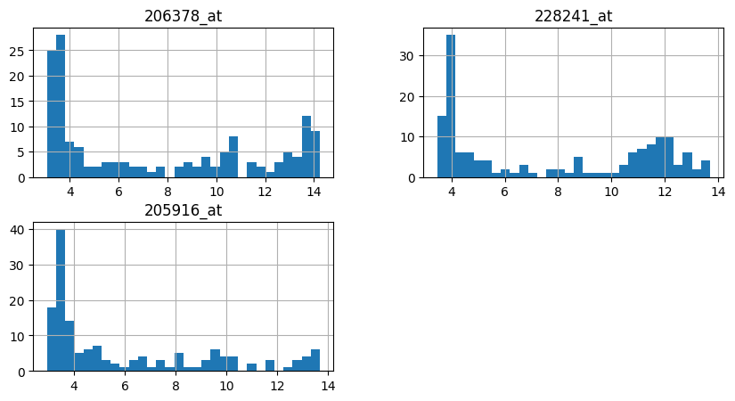

```python
df[top_genes[:3]].hist(bins=30, figsize=(10,5))
```

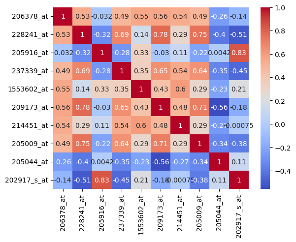

```python
import numpy as np
corr_matrix = df[top_genes].corr()
sns.heatmap(corr_matrix, annot=True, cmap='coolwarm')
```

## EDA Results

### Are these gene expressions correlated?

Gene 205916_at and 202917_s_at are highly correlated, 228241_at is correlated with 209173_at, as well as 205009_at. This is supported by the correlation matrix, where we observe high correlation coefficients among some top genes, suggesting they may be co-expressed or regulated by the same biological process.

### Which genes vary most across cancer subtypes?

Among the top genes with the highest variance, we observe that genes like `206378_at`, `228241_at`, and `205916_at` show clear differences in expression across subtypes, as seen in boxplots. This suggests they may play a role in subtype-specific gene regulation.

# data transformation decsion

We scale the data using StandardScaler because PCA and clustering algorithms are sensitive to feature magnitudes. Without scaling, genes with larger absolute values would dominate the principal components.

We do not apply log transformation here because the data appears already normalized and log-like. No missing values are present, so no imputation is required.

We also exclude metadata columns (`samples`, `type`) to ensure PCA operates only on gene expression values.

## PCA Analysis

```python
#scale data
from sklearn.preprocessing import StandardScaler
X = df.drop(columns=['type','samples'])
X_scaled = StandardScaler().fit_transform(X)
```

```python
# run PCA
from sklearn.decomposition import PCA
pca = PCA(n_components=151)
X_pca = pca.fit_transform(X_scaled)
```

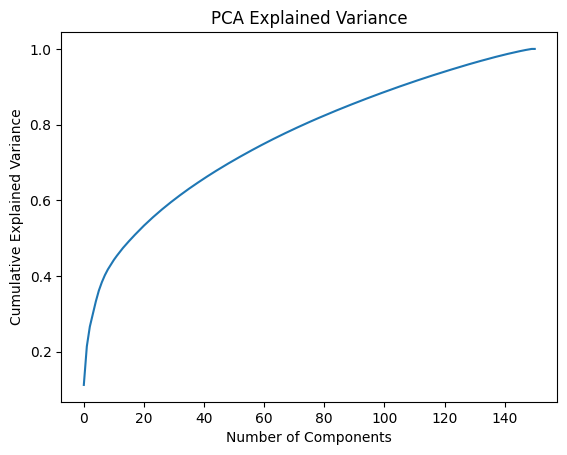

```python
# plot edxplained variance
plt.plot(np.cumsum(pca.explained_variance_ratio_))
plt.xlabel("Number of Components")
plt.ylabel("Cumulative Explained Variance")
plt.title("PCA Explained Variance")
```

### How many compenents are necessary to explain 90% of the variance

```python
n_components_90= np.where(np.cumsum(pca.explained_variance_ratio_) >= 0.9)[0][0]+1
print(f"Number of components to explain 90% variance: {n_components_90}")
```

```
Number of components to explain 90% variance: 106
```

## Clustering

I perform K-means clustering on the PCA-transformed data using the first 20 principal components as features. I am just usiong the first 20 to avoid the curse of dimensionality which causes methodologies like k- means to be less effective.

Since the dataset has 6 unique labels, I start by setting the number of clusters k = 6.

```python
from sklearn.cluster import KMeans
from sklearn.metrics import silhouette_score
k = 6
kmeans = KMeans(n_clusters=k, random_state=42)
clusters_kmeans = kmeans.fit_predict(X_pca[:, :20])
print("K-means cluster assignments:")
print(clusters_kmeans)
score_kmeans = silhouette_score(X_pca[:, :20], clusters_kmeans)
print(f"Silhouette Score (K-means, k={k}): {score_kmeans:.4f}")
```

```
K-means cluster assignments:
[2 2 2 2 2 2 2 2 2 2 2 5 5 5 5 5 5 5 5 5 5 5 5 5 5 5 5 5 5 5 5 5 5 5 5 5 4
 5 5 5 5 0 0 0 0 0 0 0 0 0 0 0 4 4 5 5 5 5 4 5 0 5 5 5 4 5 5 5 4 4 5 3 3 3
 3 3 3 3 3 3 3 3 3 3 3 1 1 1 1 1 1 1 4 4 4 4 0 4 0 0 4 4 4 4 4 4 4 4 0 0 4
 4 4 4 4 4 0 4 4 4 4 4 0 4 4 4 4 4 0 0 4 4 4 4 0 4 4 4 4 4 4 0 0 4 4 4 4 4
 4 4 4]
Silhouette Score (K-means, k=6): 0.1941
```

## Hierarchical

Next, since the score is relatively low I will perform hierarchical clustering using Ward’s linkage on the same PCA components.

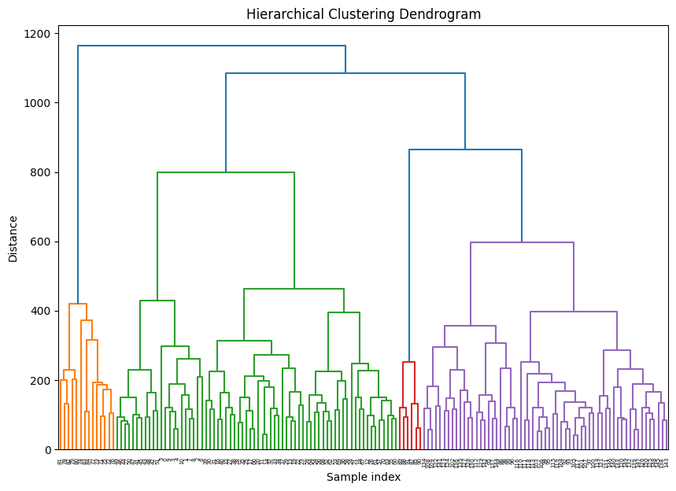

```
Silhouette Score (Hierarchical, k=6): 0.1913
```

```python
from scipy.cluster.hierarchy import linkage, dendrogram, fcluster
import matplotlib.pyplot as plt

Z = linkage(X_pca[:, :20], method='ward')

plt.figure(figsize=(10, 7))
dendrogram(Z)
plt.title("Hierarchical Clustering Dendrogram")
plt.xlabel("Sample index")
plt.ylabel("Distance")
plt.show()

clusters_hier = fcluster(Z, t=k, criterion='maxclust')

score_hier = silhouette_score(X_pca[:, :20], clusters_hier)
print(f"Silhouette Score (Hierarchical, k={k}): {score_hier:.4f}")
```

Hierarchical clustering achieved a silhouette score of 0.1913 for k=6, while K-means achieved 0.1941. For six clusters, K-means did a bit better than hierarchical clustering on silhouette score, meaning its clusters are a little tighter.

# HyperParameterTuning to get a better clustering score

Since neither the k=6 k means clustering or hierachial returned an impressive score I will perform hyoperparameter tuning to attempt to find better parameters.

```python
from scipy.cluster.hierarchy import linkage, fcluster
from sklearn.metrics import silhouette_score
import numpy as np

best_k = None
best_score = -1
scores = []

Z = linkage(X_pca[:, :20], method='ward')
for k in range(2, 26):  # start from 2 clusters
    clusters = fcluster(Z, t=k, criterion='maxclust')
    score = silhouette_score(X_pca[:, :20], clusters)
    print("score, num of clusters",(score,k))
    scores.append(score)
    if score > best_score:
        best_score = score
        best_k = k

print(f"Best number of clusters: {best_k} with silhouette score: {best_score:.4f}")
```

```
score, num of clusters (0.32929635413672254, 2)
score, num of clusters (0.1802961456191163, 3)
score, num of clusters (0.19345543695048117, 4)
score, num of clusters (0.21299764929757592, 5)
score, num of clusters (0.19125621044822225, 6)
score, num of clusters (0.17424688781311115, 7)
score, num of clusters (0.17762676166777322, 8)
score, num of clusters (0.17182108787175218, 9)
score, num of clusters (0.15394802781814607, 10)
score, num of clusters (0.15114745239429134, 11)
score, num of clusters (0.1529203239379142, 12)
score, num of clusters (0.153901408990432, 13)
score, num of clusters (0.15756516522614866, 14)
score, num of clusters (0.15833747995583577, 15)
score, num of clusters (0.15578737603476248, 16)
score, num of clusters (0.15814735804113805, 17)
score, num of clusters (0.16406985670732765, 18)
score, num of clusters (0.16515124768433345, 19)
score, num of clusters (0.16673501332189983, 20)
score, num of clusters (0.1652659343153517, 21)
score, num of clusters (0.16422525585512138, 22)
score, num of clusters (0.1662217046538982, 23)
score, num of clusters (0.1666119066745307, 24)
score, num of clusters (0.16692618820273997, 25)
Best number of clusters: 2 with silhouette score: 0.3293
```

I was looking for a way to compare the strength of the labeling and used generative AI to get ARI and NMI as methods for doing so. The Adjusted Rand Index (ARI) evaluates how well the clustering matches the true subtypes while accounting for chance, and the Normalized Mutual Information (NMI) measures the shared information between the cluster assignments and the actual classes. Using these metrics allows me to assess the quality of the unsupervised clustering, confirming that hierarchical clustering performed slightly better than KMeans in capturing the underlying biological structure.

```python
from sklearn.metrics import adjusted_rand_score, normalized_mutual_info_score
# Adjusted Rand Index (ARI) and Normalized Mutual Information (NMI)
# assess clustering quality compared to known labels, adjusted for chance.

# KMeans
ari_k = adjusted_rand_score(df['type'], clusters_kmeans)
nmi_k = normalized_mutual_info_score(df['type'], clusters_kmeans)

# Hierarchical
ari_h = adjusted_rand_score(df['type'], clusters_hier )
nmi_h = normalized_mutual_info_score(df['type'], clusters_hier )

print("KMeans ARI:", ari_k, "NMI:", nmi_k)
print("Hierarchical ARI:", ari_h, "NMI:", nmi_h)
```

```
KMeans ARI: 0.39140885486841964 NMI: 0.6004892775812123
Hierarchical ARI: 0.42634557385473565 NMI: 0.6331513458579441
```

## Discussion

- The relatively low silhouette scores for both K-means and hierarchical clustering (except for k=2 in hierarchical) indicate weak cluster structure in the dataset.
- The PCA projection may reduce noise, but the original data likely contains overlapping subtypes, instead of distinct subtypes or groups.
- The peak score at k=2 is most likely due to the model easily being able to distinguish between cancerous and noncancerous samples and is most likely not reflective of the best number of clustering groups.
- K-means has a slightly better silhouette score, which means its clusters are a bit tighter. But hierarchical clustering scores higher on ARI and NMI, meaning its clusters match the true labels better. So, even though K-means looks cleaner, hierarchical clustering groups the data in a way that fits the actual cancer subtypes more accurately.

# Conclusion